# Homework 1

```python
%matplotlib inline
from mp1 import *
from keras_tqdm import TQDMNotebookCallback
from sklearn.model_selection import train_test_split
```

```python
from keras.models import Sequential
from keras.layers import Dense, Conv2D, MaxPool2D, Reshape, Dropout, UpSampling2D, Lambda, BatchNormalization
from keras.optimizers import SGD, Adam
from keras.callbacks import EarlyStopping
```

```python
import keras.backend as K
```

```python
def normalize_train_test(x_train, x_test):
    mean, std = x_train.mean(), x_train.std()
    x_train = (x_train - mean) / std
    x_test = (x_test - mean) / std
    return x_train, x_test
```

# 2 Simple Classification

```python
[X_train, Y_train] = generate_dataset_classification(600, 20)
Y_train = to_categorical(Y_train)
X_train, X_test, Y_train, Y_test = train_test_split(X_train, Y_train, test_size=0.5)
X_train, X_test = normalize_train_test(X_train, X_test)
```

```
Creating data:
0
100
200
300
400
500
```

```python
lin_classif = Sequential([
    Dense(3, activation='softmax')
])
lin_classif.compile(optimizer=SGD(1e-2),  #SGD(),
                loss='categorical_crossentropy', metrics=['accuracy'])

lin_classif.fit(x=X_train, y=Y_train, batch_size=32, epochs=50,
            validation_split=0.15,
            verbose=0, callbacks=[TQDMNotebookCallback(leave_inner=False),
                                  EarlyStopping(patience=5, restore_best_weights=True)])

print('Stochastic Gradient Descend Optimizer')
print('test loss: {}, accuracy: {}'.format(*lin_classif.evaluate(x=X_test, y=Y_test)))
```

```
Stochastic Gradient Descend Optimizer
test loss: 0.020026730919877687, accuracy: 0.9933333333333333
```

```python
adam_lin_classif = Sequential([
    Dense(3, activation='softmax')
])
adam_lin_classif.compile(optimizer=Adam(1e-3),
                loss='categorical_crossentropy', metrics=['accuracy'])

adam_lin_classif.fit(x=X_train, y=Y_train, batch_size=32, epochs=50,
            validation_split=0.15,
            verbose=0, callbacks=[TQDMNotebookCallback(leave_inner=False),
                                  EarlyStopping(patience=5, restore_best_weights=True)])

print('Adam Optimizer')
print('test loss: {}, accuracy: {}'.format(*adam_lin_classif.evaluate(x=X_test, y=Y_test)))
```

```
Adam Optimizer
test loss: 0.017572692998995384, accuracy: 0.9933333333333333
```

On this relatively simple task, both optimizers offer good performance, and no optimizer performs significantly better than the other.

# 3 Visualization of the Solution

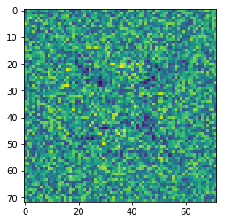

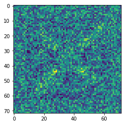

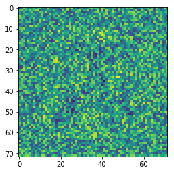

```python
linear_weights = lin_classif.get_weights()[0]

for col in linear_weights.T:
    col = (col - col.min()) / (col.max() - col.min())
    plt.imshow(col.reshape(72, 72))
    plt.show()
```

# 4 A More Difficult Classification Problem

This time we consider a much more challenging challenge, where figures can be in different locations

```python
[X_train, Y_train] = generate_dataset_classification(1000, 20, True)
Y_train = to_categorical(Y_train)
[X_test, Y_test] = generate_test_set_classification()
X_train, X_test = normalize_train_test(X_train, X_test)
```

```
Creating data:
0
100
200
300
400
500
600
700
800
900
Creating data:
0
100
200
```

### Linear Model Performances

```python
lin_classif.fit(x=X_train, y=Y_train, batch_size=32, epochs=50,
            validation_split=0.3,
            verbose=0, callbacks=[TQDMNotebookCallback(leave_inner=False),
                                  EarlyStopping(patience=5, restore_best_weights=True)])

print(lin_classif.summary())
print('Linear Model')
print('test loss: {}, accuracy: {}'.format(*lin_classif.evaluate(x=X_test, y=Y_test)))
```

```
_________________________________________________________________
Layer (type)                 Output Shape              Param #
=================================================================
dense_1 (Dense)              (None, 3)                 15555
=================================================================
Total params: 15,555
Trainable params: 15,555
Non-trainable params: 0
_________________________________________________________________
None
Linear Model
test loss: 1.0621225372950236, accuracy: 0.5800000007947286
```

On a more challenging task, classification accuracy drops and the model rapidly overfits. Overall model is very bad, as a linear model which associates a weight to each pixel is not designed to successfully classify geometric figures in different positions.

### Convolutional Network

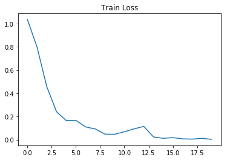

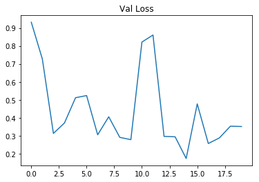

```
_________________________________________________________________
Layer (type)                 Output Shape              Param #
=================================================================
conv2d_13 (Conv2D)           (None, 70, 70, 4)         40
_________________________________________________________________
dropout_4 (Dropout)          (None, 70, 70, 4)         0
_________________________________________________________________
max_pooling2d_10 (MaxPooling (None, 35, 35, 4)         0
_________________________________________________________________
conv2d_14 (Conv2D)           (None, 33, 33, 4)         148
_________________________________________________________________
max_pooling2d_11 (MaxPooling (None, 16, 16, 4)         0
_________________________________________________________________
conv2d_15 (Conv2D)           (None, 14, 14, 8)         296
_________________________________________________________________
max_pooling2d_12 (MaxPooling (None, 7, 7, 8)           0
_________________________________________________________________
conv2d_16 (Conv2D)           (None, 5, 5, 16)          1168
_________________________________________________________________
reshape_4 (Reshape)          (None, 400)               0
_________________________________________________________________
dense_6 (Dense)              (None, 3)                 1203
=================================================================
Total params: 2,855
Trainable params: 2,855
Non-trainable params: 0
_________________________________________________________________
None
test loss: 0.07916280666987101, accuracy: 0.9733333341280619
```

```python
X_train = X_train.reshape(-1, 72, 72, 1)
X_test = X_test.reshape(-1, 72, 72, 1)

def conv_model():
    conv_classif = Sequential([
        Conv2D(filters=4, kernel_size=3, activation='relu'),
        Dropout(rate=0.3),
        MaxPool2D(pool_size=(2, 2)),
        Conv2D(filters=4, kernel_size=3, activation='relu'),
        MaxPool2D(pool_size=(2, 2)),
        Conv2D(filters=8, kernel_size=3, activation='relu'),
        MaxPool2D(pool_size=(2, 2)),
        Conv2D(filters=16, kernel_size=3, activation='relu'),
        Reshape(target_shape=(-1,)),
        Dense(3, activation='softmax')])

    conv_classif.compile(optimizer=Adam(1e-2),
                         loss='categorical_crossentropy', metrics=['accuracy'])
    return conv_classif

conv_classif = conv_model()
losses = conv_classif.fit(x=X_train, y=Y_train, batch_size=32, epochs=100,
            validation_split=0.15,
            verbose=0, callbacks=[TQDMNotebookCallback(leave_inner=False),
                                  EarlyStopping(patience=5, restore_best_weights=True)
                                 ])

plt.plot(losses.history['loss'])
plt.title("Train Loss")
plt.show()
plt.plot(losses.history['val_loss'])
plt.title("Val Loss")
plt.show()

print(conv_classif.summary())
print('test loss: {}, accuracy: {}'.format(*conv_classif.evaluate(x=X_test, y=Y_test)))
```

Considered model here achieves an almost perfect average accuracy, with fewer parameters than the previous model.

# 5 A Regression Problem

```python
def normalize_vertices(Y):
    Y_vals = Y.reshape((-1, 3, 2))
    new_y = []
    for positions in Y_vals:
        sorted_vertices  = np.argsort(positions[:, 0])
        sorted_positions = positions[sorted_vertices]
        min_positions = sorted_positions[0, :]
#         sorted_positions[1, :] -= min_positions
#         sorted_positions[2, :] -= min_positions
        new_y.append(sorted_positions)
    return np.array(new_y).reshape(-1, 6)

[X_train, Y_train] = generate_dataset_regression(1000, 20)
[X_test, Y_test] = generate_test_set_regression()

mean, std = X_train.mean(), X_train.std()
X_train = (X_train - mean) / std
X_test = (X_test - mean) / std

X_train = X_train.reshape(-1, 72, 72, 1)
X_test = X_test.reshape(-1, 72, 72, 1)

Y_train_norm = normalize_vertices(Y_train)
Y_test_norm = normalize_vertices(Y_test)
```

```
Creating data:
0
100
200
300
400
500
600
700
800
900
Creating data:
0
100
200
```

**Normalization step**: as it is, the network has no way to know the order in which it should yield point coordinates. Thus, we need to feed (both in training and testing) the coordinates in a structured order. *normalize_vertices* function sort vertices by increasing absisse.

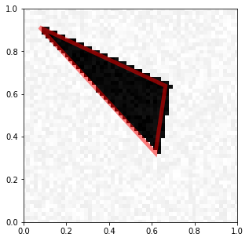

```python
visualize_prediction(X_train[1], Y_train_norm[1])
```

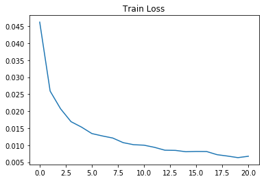

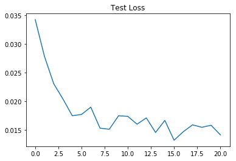

```python
def reg_conv_model():
    conv_reg = Sequential([
        Conv2D(filters=4, kernel_size=3, activation='relu'),
        Dropout(rate=0.3),
        MaxPool2D(pool_size=(2, 2)),
        Conv2D(filters=4, kernel_size=3, activation='relu'),
        MaxPool2D(pool_size=(2, 2)),
        Conv2D(filters=8, kernel_size=3, activation='relu'),
        MaxPool2D(pool_size=(2, 2)),
        Conv2D(filters=16, kernel_size=3, activation='relu'),
        Reshape(target_shape=(-1,)),
        Dense(6, activation='sigmoid'),
    ])

    conv_reg.compile(optimizer=Adam(1e-2),
                    loss='mse')
    return conv_reg

conv_reg = reg_conv_model()
losses = conv_reg.fit(x=X_train, y=Y_train_norm, batch_size=32, epochs=100,
            validation_split=0.15,
            verbose=0, callbacks=[TQDMNotebookCallback(leave_inner=False),
                                  EarlyStopping(patience=5, restore_best_weights=True)
                                 ])
Y_pred = conv_reg.predict(X_test)
plt.plot(losses.history['loss'])
plt.title("Train Loss")
plt.show()
plt.plot(losses.history['val_loss'])
plt.title("Test Loss")
plt.show()
```

```python
conv_reg.summary()
```

```
_________________________________________________________________
Layer (type)                 Output Shape              Param #
=================================================================
conv2d_17 (Conv2D)           (None, 70, 70, 4)         40
_________________________________________________________________
dropout_5 (Dropout)          (None, 70, 70, 4)         0
_________________________________________________________________
max_pooling2d_13 (MaxPooling (None, 35, 35, 4)         0
_________________________________________________________________
conv2d_18 (Conv2D)           (None, 33, 33, 4)         148
_________________________________________________________________
max_pooling2d_14 (MaxPooling (None, 16, 16, 4)         0
_________________________________________________________________
conv2d_19 (Conv2D)           (None, 14, 14, 8)         296
_________________________________________________________________
max_pooling2d_15 (MaxPooling (None, 7, 7, 8)           0
_________________________________________________________________
conv2d_20 (Conv2D)           (None, 5, 5, 16)          1168
_________________________________________________________________
reshape_5 (Reshape)          (None, 400)               0
_________________________________________________________________
dense_7 (Dense)              (None, 6)                 2406
=================================================================
Total params: 4,058
Trainable params: 4,058
Non-trainable params: 0
_________________________________________________________________
```

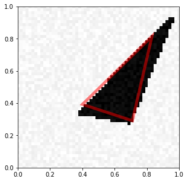

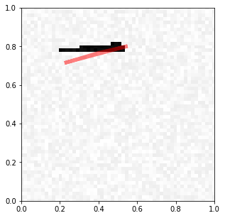

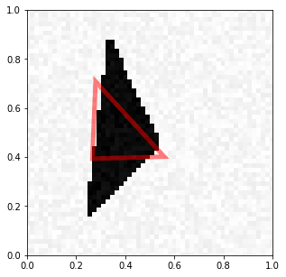

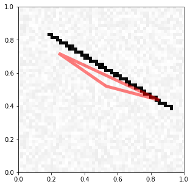

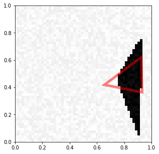

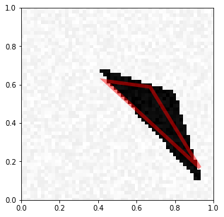

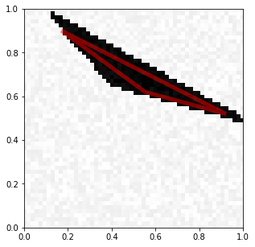

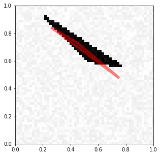

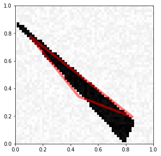

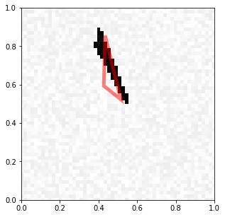

```python
for idx in range(10):
    visualize_prediction(X_test[idx], Y_pred[idx])
```

We can see that without being perfect, our regressor achieves interesting performance in this task.

# 6 Bonus Question

Instead of adding noise to images offline I prefer to add noise online during training for simplicity, and also because obtained models will overfit way less than in an online fashion

```python
[X_train, Y_train] = generate_dataset_classification(1000, noise=0, free_location=True)
np.random.seed(100010)
[X_test, Y_test] =generate_dataset_classification(300, noise=0, free_location=True)

mean, std = X_train.mean(), X_train.std()
X_train = (X_train - mean) / std
X_test = (X_test - mean) / std

X_train = X_train.reshape(-1, 72, 72, 1)
X_test = X_test.reshape(-1, 72, 72, 1)
```

```
Creating data:
0
100
200
300
400
500
600
700
800
900
Creating data:
0
100
200
```

```python
def noise_layer(ipt):
    amplitudes = np.random.uniform(low=0.5, high=0.8)
    noise = K.random_normal(shape=K.shape(ipt), mean=0.0,  # (BATCH_SIZE, 72, 72, 1)
                            stddev=amplitudes)

    return ipt + noise

def denoising_autoencoder():
    mdl = Sequential(layers=[
        Lambda(noise_layer, output_shape=(72, 72, 1), input_shape=(72, 72, 1)),
        Conv2D(filters=4, kernel_size=3, activation='relu', padding='same', input_shape=(72, 72, 1)),
        Dropout(rate=0.3),
        MaxPool2D(pool_size=(2, 2)),
        Conv2D(filters=4, kernel_size=3, activation='relu', padding='same',),
        MaxPool2D(pool_size=(2, 2)),
        Conv2D(filters=8, kernel_size=3, activation='relu', padding='same',),
        MaxPool2D(pool_size=(2, 2)),
        BatchNormalization(),

        Conv2D(filters=8, kernel_size=3, activation='relu', padding='same',),
        UpSampling2D(size=(2, 2), interpolation='bilinear'),
        Conv2D(filters=4, kernel_size=3, activation='relu', padding='same',),
        UpSampling2D(size=(2, 2), interpolation='bilinear'),
        Conv2D(filters=4, kernel_size=3, activation='relu', padding='same',),
        UpSampling2D(size=(2, 2), interpolation='bilinear'),
        Conv2D(filters=4, kernel_size=3, activation='relu', padding='same',),
        Conv2D(filters=1, kernel_size=1, activation='linear', padding='same',),
#         Conv2D(filters=1, kernel_size=1, activation='linear', padding='same', use_bias=False),
    ])
    mdl.compile(optimizer=Adam(1e-2),
                    loss='mse')
    return mdl

mdl = denoising_autoencoder()
mdl.summary()
```

```
_________________________________________________________________
Layer (type)                 Output Shape              Param #
=================================================================
lambda_1 (Lambda)            (None, 72, 72, 1)         0
_________________________________________________________________
conv2d_21 (Conv2D)           (None, 72, 72, 4)         40
_________________________________________________________________
dropout_6 (Dropout)          (None, 72, 72, 4)         0
_________________________________________________________________
max_pooling2d_16 (MaxPooling (None, 36, 36, 4)         0
_________________________________________________________________
conv2d_22 (Conv2D)           (None, 36, 36, 4)         148
_________________________________________________________________
max_pooling2d_17 (MaxPooling (None, 18, 18, 4)         0
_________________________________________________________________
conv2d_23 (Conv2D)           (None, 18, 18, 8)         296
_________________________________________________________________
max_pooling2d_18 (MaxPooling (None, 9, 9, 8)           0
_________________________________________________________________
batch_normalization_1 (Batch (None, 9, 9, 8)           32
_________________________________________________________________
conv2d_24 (Conv2D)           (None, 9, 9, 8)           584
_________________________________________________________________
up_sampling2d_1 (UpSampling2 (None, 18, 18, 8)         0
_________________________________________________________________
conv2d_25 (Conv2D)           (None, 18, 18, 4)         292
_________________________________________________________________
up_sampling2d_2 (UpSampling2 (None, 36, 36, 4)         0
_________________________________________________________________
conv2d_26 (Conv2D)           (None, 36, 36, 4)         148
_________________________________________________________________
up_sampling2d_3 (UpSampling2 (None, 72, 72, 4)         0
_________________________________________________________________
conv2d_27 (Conv2D)           (None, 72, 72, 4)         148
_________________________________________________________________
conv2d_28 (Conv2D)           (None, 72, 72, 1)         5
=================================================================
Total params: 1,693
Trainable params: 1,677
Non-trainable params: 16
_________________________________________________________________
```

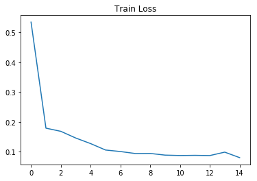

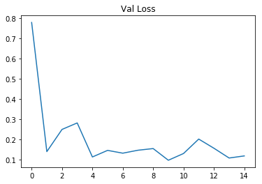

```python
losses = mdl.fit(x=X_train, y=X_train, batch_size=32,
                 epochs=100,
            validation_split=0.15,
            verbose=0, callbacks=[TQDMNotebookCallback(leave_inner=False),
                                  EarlyStopping(patience=5, restore_best_weights=True)
                                 ])
plt.plot(losses.history['loss'])
plt.title("Train Loss")
plt.show()
plt.plot(losses.history['val_loss'])
plt.title("Val Loss")
plt.show()
```

```python
X_test_pred = mdl.predict(X_test)
X_test_pred = X_test_pred*std + mean
X_test_noisy = X_test + 0.8*np.random.normal(size=X_test.shape)
X_test_noisy = X_test_noisy*std + mean
```

```python
def postprocess_X(X_pred_renorm):
    X_treated = X_pred_renorm.copy()
    X_treated[X_treated < 0.5] = 0.0
    X_treated[X_treated > 0.5] = 1.0
    return X_treated
```

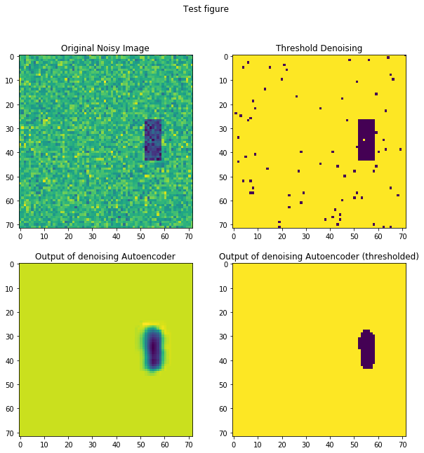

```python
idx = 20

X_test_pred_post = postprocess_X(X_test_pred)
X_test_noisy_post = postprocess_X(X_test_noisy)

fig, axes = plt.subplots(nrows=2, ncols=2, figsize=(10, 10))
axes[0, 0].imshow(X_test_noisy[idx].reshape((72, 72)))
axes[0, 0].set_title('Original Noisy Image')
axes[0, 1].imshow(X_test_noisy_post[idx].reshape((72, 72)))
axes[0, 1].set_title('Threshold Denoising')
axes[1, 0].imshow(X_test_pred[idx].reshape((72, 72)))
axes[1, 0].set_title('Output of denoising Autoencoder')
axes[1, 1].imshow(X_test_pred_post[idx].reshape((72, 72)))
axes[1, 1].set_title('Output of denoising Autoencoder (thresholded)')

plt.suptitle('Test figure')
plt.show()
```

In this model, I used a lot of noise into the images. This is motivated by the fact that a denoising binary images with low noise is trivial

In above graph, the upper right image represents the denoised prediction we obtain by simply using a $0.5$ threshold. We can clearly see it is very bad, as there still is noise pretty much everywhere.

Lower figures show respectively the scores of the output of the denoising autoencoder, and the corresponding binary denoised image. There is no more noise corresponding to isolated points. This is a great improvement over the naive method. That being said, figure no longer is a rectangle, du to very high noise. As I already said, this is also linked to the fact that there is huge noise in these images (Gaussian noise with $\sigma=0.8$)